# EDA of Red Wine Quality Data

Let’s see what a linear model looks like on top of these data.

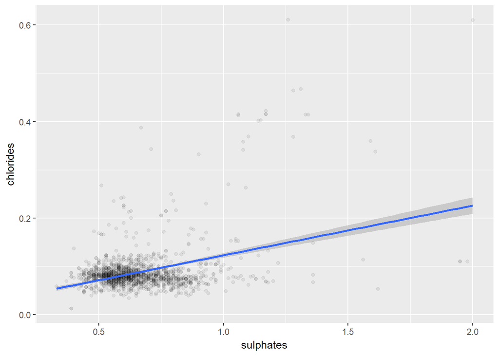

```r
ggplot(wine_quality, aes(x = sulphates, y = chlorides)) +
  geom_point(alpha = 1/15) +
  stat_smooth(method = "lm")
```

This was what I was expecting. This doesn’t seem to be a meaningful relationship.

There seems to be a fairly strong relationship between volatile.acidity and citric.acid.

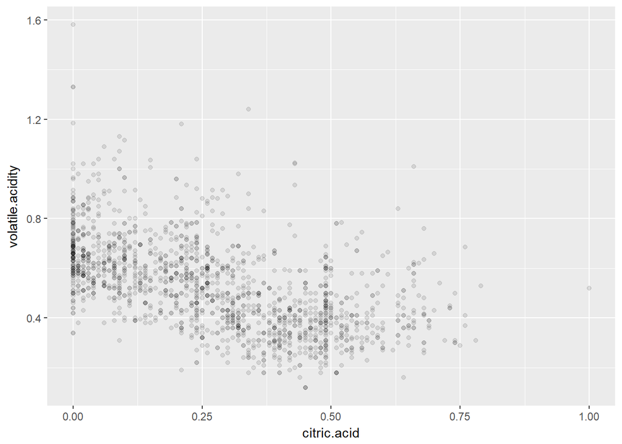

```r
ggplot(wine_quality, aes(x = citric.acid, y = volatile.acidity)) +
  geom_point(alpha = 1/10)
```

There is a wide range of volatile.acidity values for each citric.acid measurement. There does seems to be a negative correlation here but the variance would be quite high. The bands of common citric.acid measurements (0.0, 0.24, and 0.49) that were noted during the uni-variate exploration are visible here. Visually, it seems that beyond citric.acid measurements of 0.49 the trend reverses and begins upward.

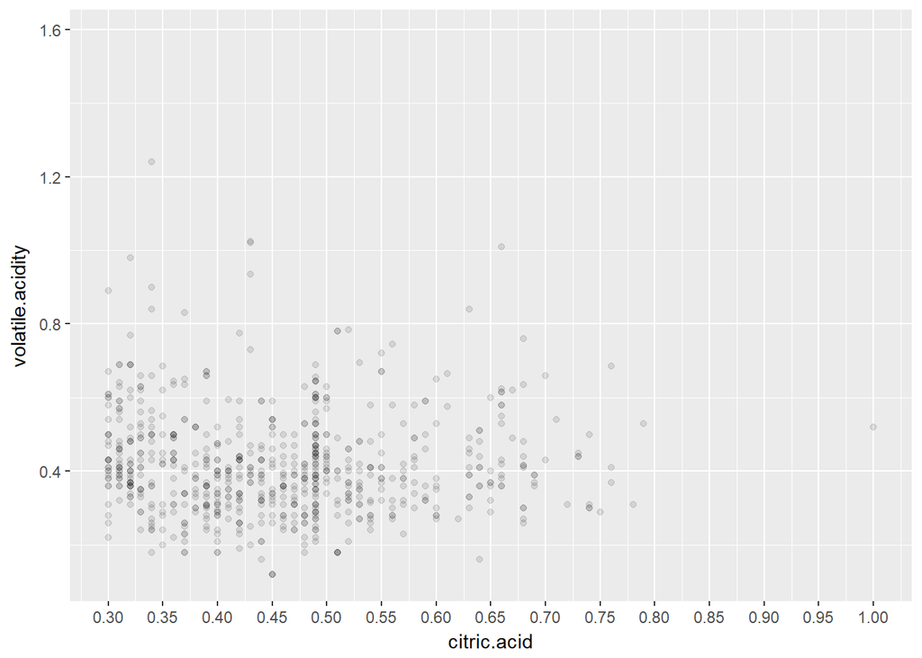

```r
ggplot(wine_quality, aes(x = citric.acid, y = volatile.acidity)) +
  geom_point(alpha = 1/10) +
  scale_x_continuous(limits = c(0.3, 1.0), breaks = seq(0.3, 1.0, 0.05))
```

Actually, the trend seems to be fairly flat from around citric.acid measurements > 0.35.

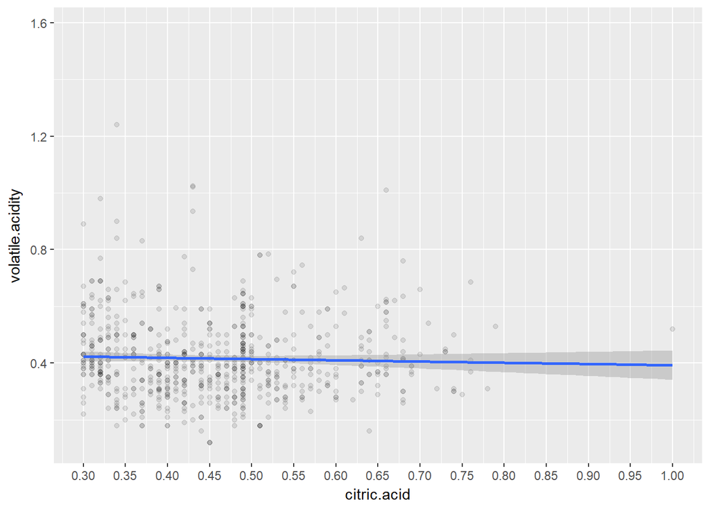

```r
ggplot(wine_quality, aes(x = citric.acid, y = volatile.acidity)) +
  geom_point(alpha = 1/10) +
  scale_x_continuous(limits = c(0.3, 1.0), breaks = seq(0.3, 1.0, 0.05)) +
  stat_smooth(method = "lm")
```

Superimposing a linear model confirms the tendency is approaching flat but still slightly negative.

The fixed.acidity and citric.acid measurements appear to have a very strong correlation. I was going to ignore this relationship until I read the description of each of the variables again. I was under the impression that the fixed.acidity measurement was a measurement of all acidity except acetic acid. Since this is not the case let’s investigate this relationship.

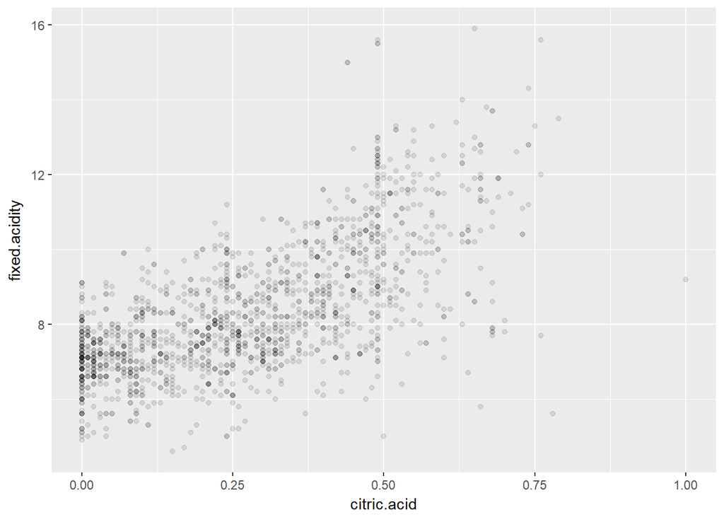

```r
ggplot(wine_quality, aes(x = citric.acid, y = fixed.acidity)) +
  geom_point(alpha = 1/10)
```

Visually, there seems to be an exponential curve. Let’s see what log(fixed.acidity) looks like.

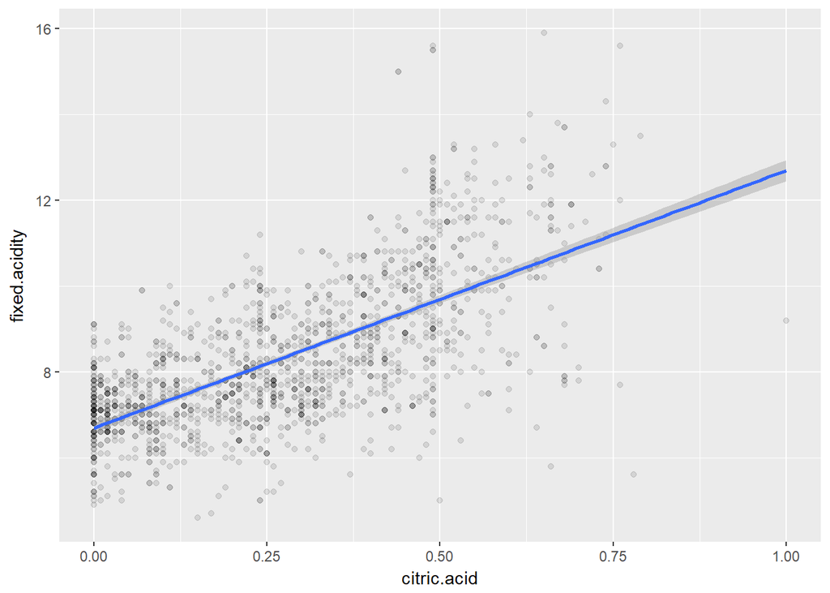

```r
ggplot(wine_quality, aes(x = citric.acid, y = fixed.acidity)) +
  geom_point(alpha = 1/10) +
  stat_smooth(method = "lm")
```

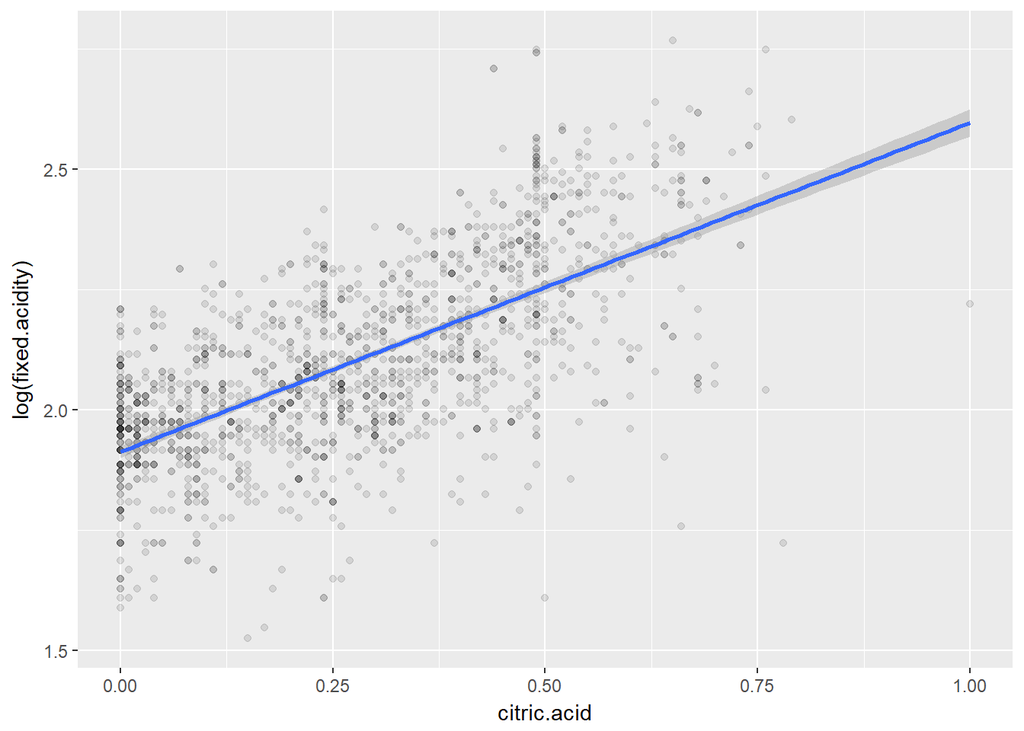

```r
ggplot(wine_quality, aes(x = citric.acid, y = log(fixed.acidity))) +
  geom_point(alpha = 1/10) +
  stat_smooth(method = "lm")
```

With the linear model overlay over the original plot the cure is no longer perceptible. The log(fixed.acidity) plot may have slightly normalized the distribution linearly but it is very difficult to tell.

At the outset I was expecting alcohol and residual.sugars to be more related than their correlation indicates. Let’s have a look at the plot anyway.

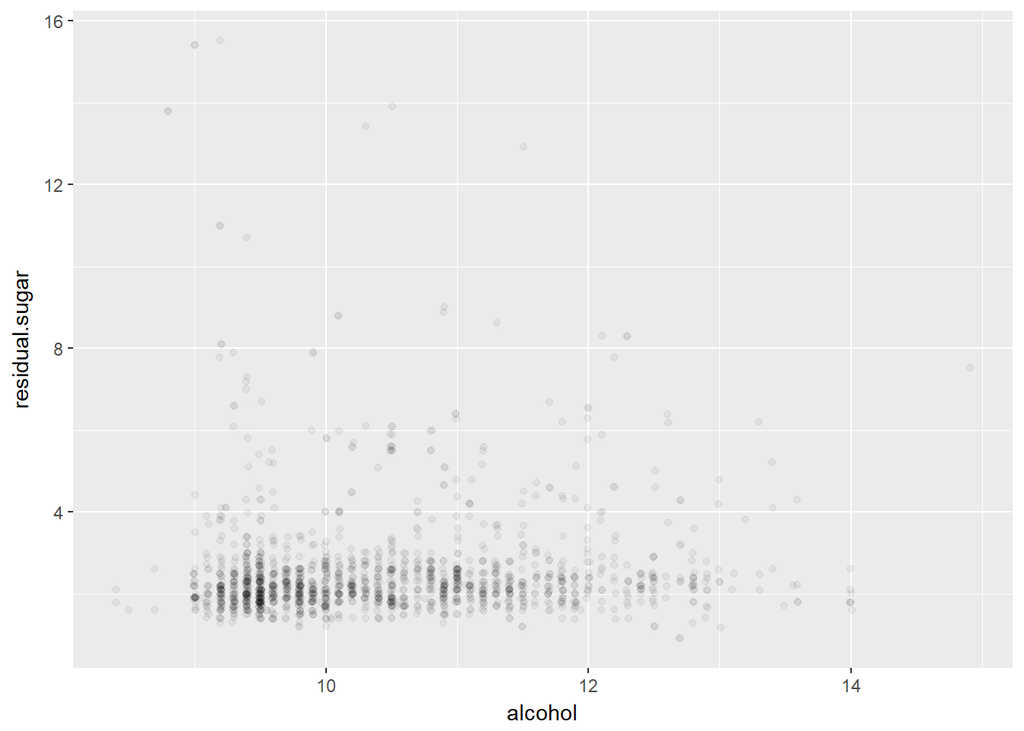

```r
ggplot(wine_quality, aes(x = alcohol, y = residual.sugar)) +
  geom_point(alpha = 1/20, position = position_jitter(0.01))
```

Here we are reminded of the results from the uni-variate analysis of residual.sugar - most wine having a measurement of 2 g/L.

# Bivariate Analysis

### Talk about some of the relationships you observed in this part of the investigation. How did the feature(s) of interest vary with other features in the dataset?

There seem to be two variable that are driving the variance in the quality variable. Higher alcohol content tends to produce better scores. Lower volatile.acidity tends to produce higher scores. There were some other notable and surprising relationships. The sulfate measurements have a mild effect on the quality score. This was something unexpected for me.

### Did you observe any interesting relationships between the other features (not the main feature(s) of interest)?

There is a moderate, negative relationship between the volatile.acidity measurements and the citric.acid measurements. I wasn’t expecting these two measurements to be related. Chlorides and Sulfates seems to have a relationship but I am not sure if it is significant. I was expecting alcohol and residual.sugar to have some relationship but they do not. A couple times in areas of certain scatter plots where the density was lower there appeared to be a visually identifiable trend but by adding an additional visual element to the plot (a linear smoother) these trends usually stopped being perceptible.

### What was the strongest relationship you found?

The strongest relationship I analyzed was between fixed.acidity and citric.acid. This relationship has a 0.7 Pearson correlation coefficient.

# Multivariate Plots Section

Let’s have a look at all the pairs so I know where to spend additional time:

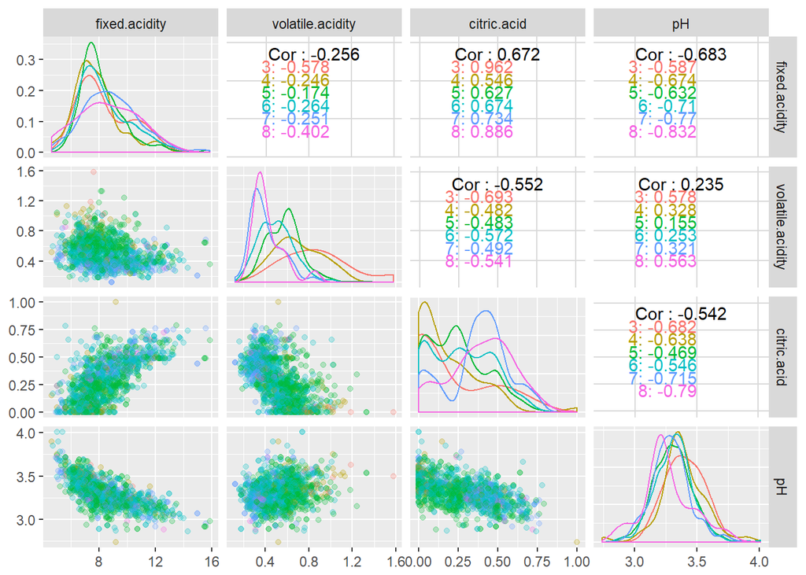

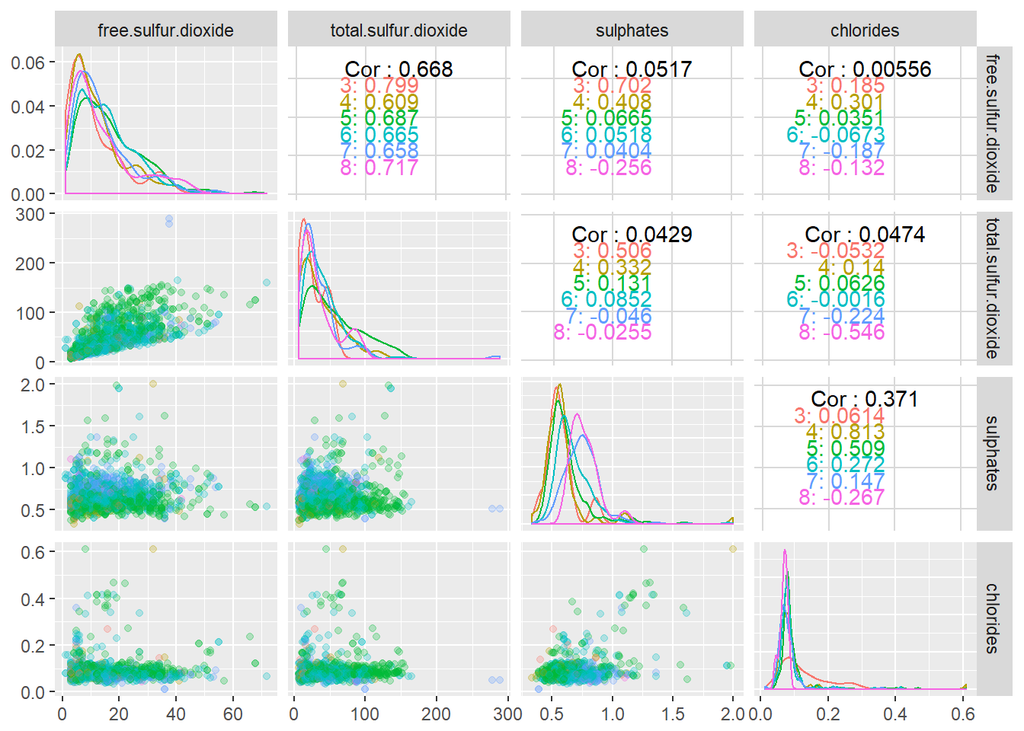

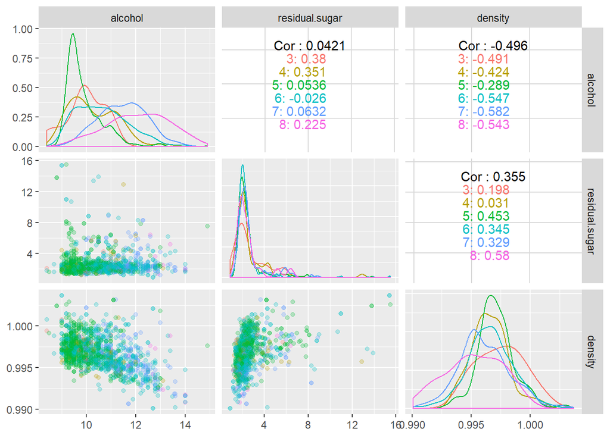

The density plots on the diagonals in the ggpairs plots seem to offer some solid insight so I wanted to try and plot them all at once:

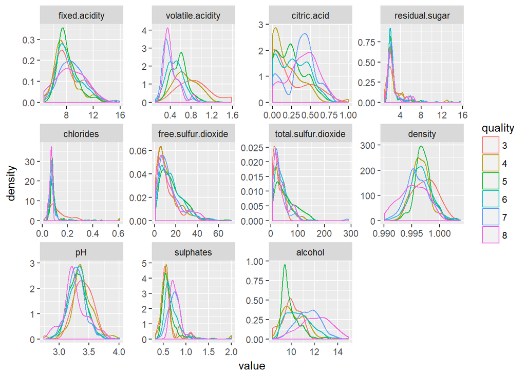

That seems to do the trick. In the fixed.acidity plot we can see quality scores of 7 and 8 have a slightly higher mean. In the volatile.acidity plot higher scores have lower means and lower scores have higher means. For citric.acid measurements higher values produce higher scores. In the pH plot we can see a proxy effect reflected in the results from the other acidity related variables. In the sulfate plot we see our higher scoring wines pulling away from the other having a higher mean sulfate measurements. Finally, the alcohol plot illustrates higher scoring wines have higher alcohol content.

I’d like to examine each of the relationships I have discovered thus far with a focus on conditioning on quality and bucketed alcohol content. I will bucket the alcohol variable in to “Low”, “Medium”, and “High”. “Low” will be alcohol contents between 0 and -1 standard deviation. “Medium” will contain wines with -1 standard deviation to +1 standard deviation alcohol. “High” will represent +1 standard deviation to the max value of the alcohol variable.

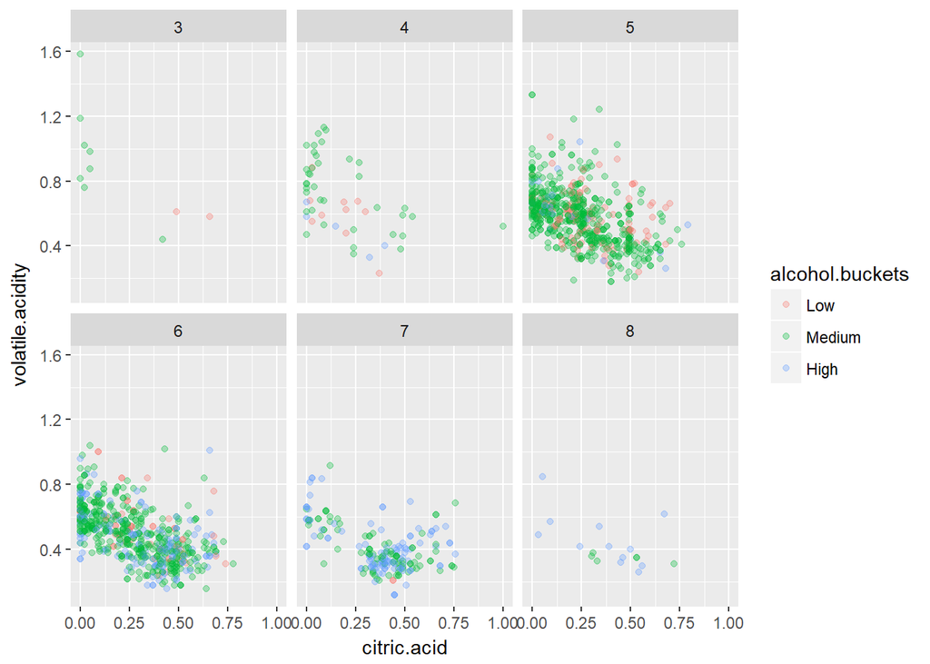

Between scores of 5 and 6 we can see the effect of the alcohol variable emerging. The plots for scores of 5 and 6 have very similar volatile.acidity to citric.acid characteristics, but in the we can see that 6 has several more wines from the ‘High’ alcohol bucket and fewer from the ‘Low’ bucket. Examining the highest scores of 7 and 8 we can see the occurrence of ‘Medium’ alcohol bucket observations drop off being replaced with ‘High’ alcohol observations. As the score improves we can see that the range of volatile.acidity compresses around the 0.4 measurement.

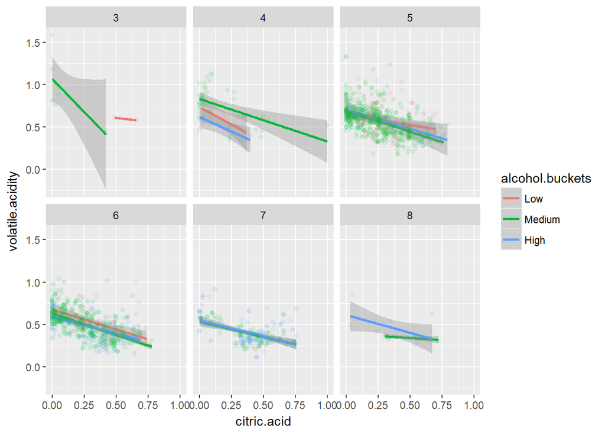

Overlaying a linear model conditioned on alcohol.buckets we can see the slopes are all roughly similar for the scores with the most data available, 5 through 7. The effect that alcohol has on the volatile.acidity ~ citric.acid relationship is minor.

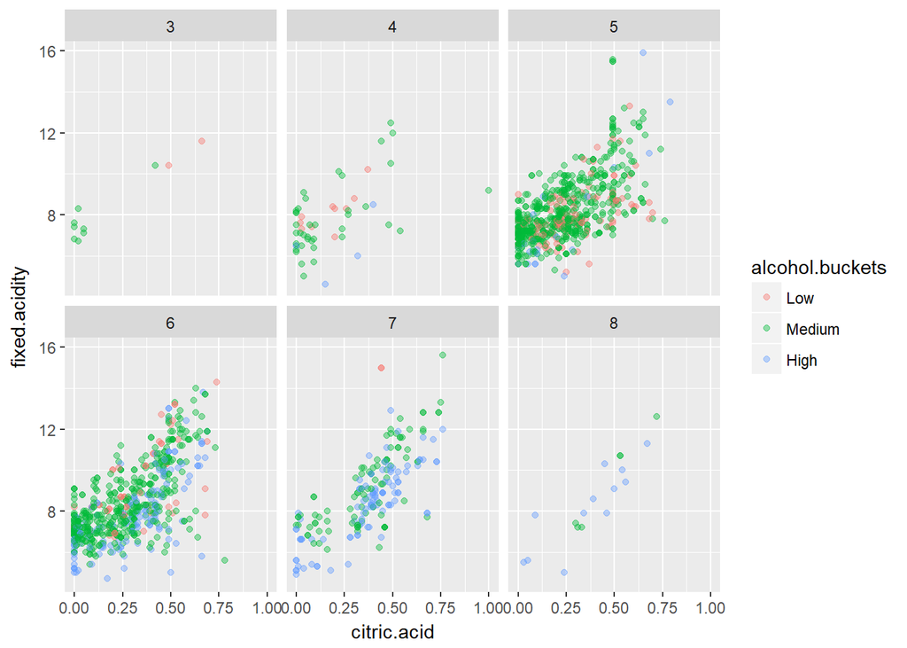

Seems like the fixed.acidity ~ citric.acid relationship is fairly consistent across the quality scores.

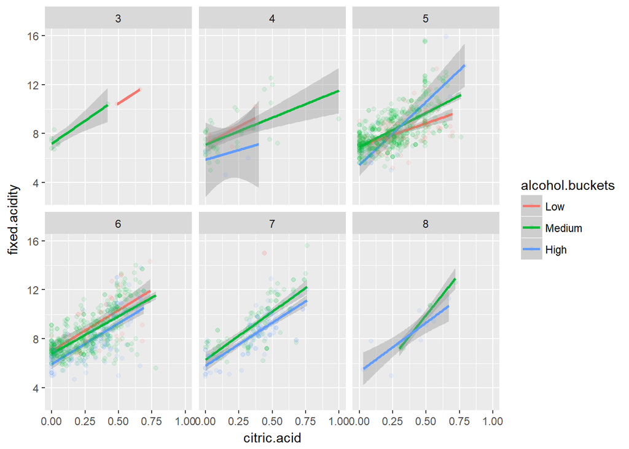

The linear model exposes a few hidden trends that were buried in over-plotting. Between scores of 5 to 7 the fixed.acidity ~ citric.acid relationship conditioned on alcohol.buckets changes slightly. The facet for quality scores of 5 could be skewing the slope of the “High” alcohol bucket due to sparse observations with those parameters. It is interesting that there is a slight fixed.acidity offset in the slopes for the alcohol buckets in several of the facets.

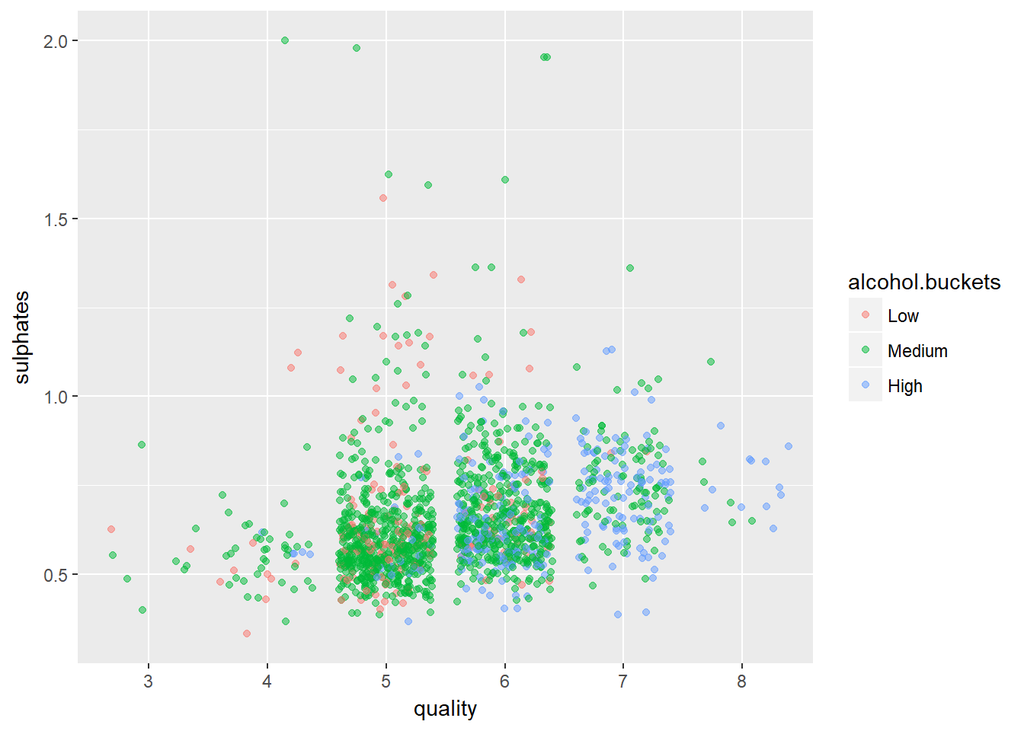

The sulfates ~ quality and alcohol ~ quality positive relationships can be observed here.

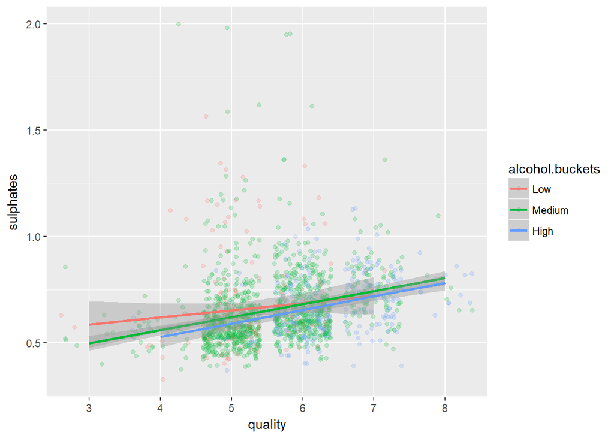

The sulfate ~ quality relationship seems to be slightly different for the “Low” alcohol bucket. For the other alcohol buckets the relationship is consistent, the slopes are roughly equal with the “High” bucket having slightly lower sulfate measurements.

Let’s see what kind of predictive power the features in this data set have.

```
##
## Calls:
## m1: lm(formula = quality ~ alcohol, data = wq)
## m2: lm(formula = quality ~ alcohol + volatile.acidity, data = wq)
## m3: lm(formula = quality ~ alcohol + volatile.acidity + fixed.acidity,
##     data = wq)
## m4: lm(formula = quality ~ alcohol + volatile.acidity + fixed.acidity +
##     sulphates, data = wq)
## m4.1: lm(formula = quality ~ alcohol + volatile.acidity + fixed.acidity +
##     sulphates + density, data = wq)
## m4.2: lm(formula = quality ~ alcohol + volatile.acidity + fixed.acidity +
##     sulphates + density + pH, data = wq)
## m5: lm(formula = quality ~ alcohol + volatile.acidity + fixed.acidity +
##     sulphates + density + pH + total.sulfur.dioxide, data = wq)
## m6: lm(formula = quality ~ alcohol + volatile.acidity + fixed.acidity +
##     sulphates + density + pH + total.sulfur.dioxide + free.sulfur.dioxide,
##     data = wq)
## m7: lm(formula = quality ~ alcohol + volatile.acidity + fixed.acidity +
##     sulphates + density + pH + total.sulfur.dioxide + free.sulfur.dioxide +
##     residual.sugar, data = wq)
## m8: lm(formula = quality ~ alcohol + volatile.acidity + fixed.acidity +
##     sulphates + density + pH + total.sulfur.dioxide + free.sulfur.dioxide +
##     residual.sugar + chlorides, data = wq)
## m9: lm(formula = quality ~ alcohol + volatile.acidity + fixed.acidity +
##     sulphates + density + pH + total.sulfur.dioxide + free.sulfur.dioxide +
##     residual.sugar + chlorides + citric.acid, data = wq)
##
## ========================================================================================================================================================
##                            m1         m2         m3         m4        m4.1        m4.2         m5          m6          m7          m8          m9
## --------------------------------------------------------------------------------------------------------------------------------------------------------
##   (Intercept)           1.875***   3.095***   2.674***   2.313***   32.216*     30.545      19.765      19.141      31.890      22.238      21.965
##                        (0.175)    (0.184)    (0.218)    (0.223)    (15.202)    (16.906)    (17.034)    (17.014)    (21.265)    (21.197)    (21.195)
##   alcohol               0.361***   0.314***   0.321***   0.315***    0.291***    0.294***    0.293***    0.292***    0.279***    0.271***    0.276***
##                        (0.017)    (0.016)    (0.016)    (0.016)     (0.020)     (0.023)     (0.023)     (0.023)     (0.026)     (0.026)     (0.026)
##   volatile.acidity                -1.384***  -1.286***  -1.155***   -1.115***   -1.114***   -1.110***   -1.086***   -1.080***   -1.003***   -1.084***
##                                   (0.095)    (0.099)    (0.100)     (0.102)     (0.102)     (0.101)     (0.102)     (0.102)     (0.102)     (0.121)
##   fixed.acidity                               0.036***   0.028**     0.049***    0.045*      0.023       0.023       0.034       0.014       0.025
##                                              (0.010)    (0.010)     (0.015)     (0.021)     (0.022)     (0.022)     (0.024)     (0.024)     (0.026)
##   sulphates                                              0.642***    0.677***    0.672***    0.688***    0.679***    0.702***    0.913***    0.916***
##                                                         (0.101)     (0.103)     (0.105)     (0.105)     (0.104)     (0.107)     (0.114)     (0.114)
```

[output cut: 11 more lines]

```
##                                                                                                                                 (0.405)     (0.419)
##   citric.acid                                                                                                                               -0.183
##                                                                                                                                             (0.147)
## --------------------------------------------------------------------------------------------------------------------------------------------------------
##   R-squared                 0.2        0.3        0.3        0.3         0.3         0.3         0.3         0.3         0.3         0.4         0.4
##   adj. R-squared            0.2        0.3        0.3        0.3         0.3         0.3         0.3         0.3         0.3         0.4         0.4
##   sigma                     0.7        0.7        0.7        0.7         0.7         0.7         0.7         0.7         0.7         0.6         0.6
##   F                       468.3      370.4      253.1      204.5       164.6       137.1       121.0       106.8        95.1        89.3        81.3
##   p                         0.0        0.0        0.0        0.0         0.0         0.0         0.0         0.0         0.0         0.0         0.0
##   Log-likelihood        -1721.1    -1621.8    -1615.4    -1595.5     -1593.6     -1593.6     -1585.4     -1582.8     -1582.3     -1569.9     -1569.1
##   Deviance                805.9      711.8      706.1      688.8       687.1       687.1       680.1       677.9       677.4       667.1       666.4
##   AIC                    3448.1     3251.6     3240.8     3203.1      3201.2      3203.1      3188.7      3185.5      3186.5      3163.8      3164.3
##   BIC                    3464.2     3273.1     3267.6     3235.3      3238.8      3246.1      3237.1      3239.3      3245.7      3228.4      3234.2
##   N                      1599       1599       1599       1599        1599        1599        1599        1599        1599        1599        1599
## ========================================================================================================================================================
```

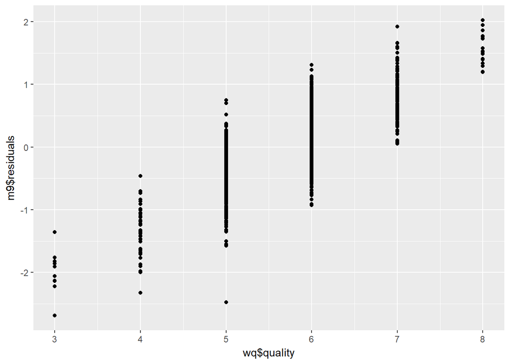

Each variable was added to the linear model on by one to assess the impact on the model’s score. mtable provides a convenient output to compare the impact of each additional feature to the model. We can see that the score of this model is quite poor. The residual plot illustrates it clearly. It is understandable that score of 5 and 6 are generally closer to 0 since most of the wines in the data set have quality scores in that range. Despite that the linear model’s output varies far too wildly to be useful. Additional features would need to be considered to product a more accurate model. Region and economic data would be a good start.

# Multivariate Analysis

### Talk about some of the relationships you observed in this part of the investigation. Were there features that strengthened each other in terms of looking at your feature(s) of interest?

In this section I was primarily focused on how some of the correlated physio-chemical variables behaved when conditioned on quality and alcohol.buckets. alcohol.buckets was prepared using the alcohol variable cut using the standard deviation as boundaries. The relationships that were reexamined from this perspective were fixed.acidity ~ citric.acid, volatile.acidity ~ citric.acid, sulfates ~ quality. There appeared to be minor variances across quality and bucketed alcohol values but the general trends that were observed during the bi-variate analysis were consistent.

### Were there any interesting or surprising interactions between features?

For some of the relationships exhibited minor differences when conditioned on bucketed alcohol content and quality by the gross trends remained consistent.

### OPTIONAL: Did you create any models with your dataset? Discuss the strengths and limitations of your model.

A simple linear model was constructed using quality as the dependent variable. The model produced an R-squared value of 0.4 when using all of the variables available. The red wine data set has an extensive profile of physio-chemical measurements but it would seem that since the quality score is human generated and subjective that there are other features that are missing from these data that could improve a predictive model. A linear model might also be too simple to effective decision boundaries. Perhaps another algorithm would perform better.

# Final Plots and Summary

### Plot One

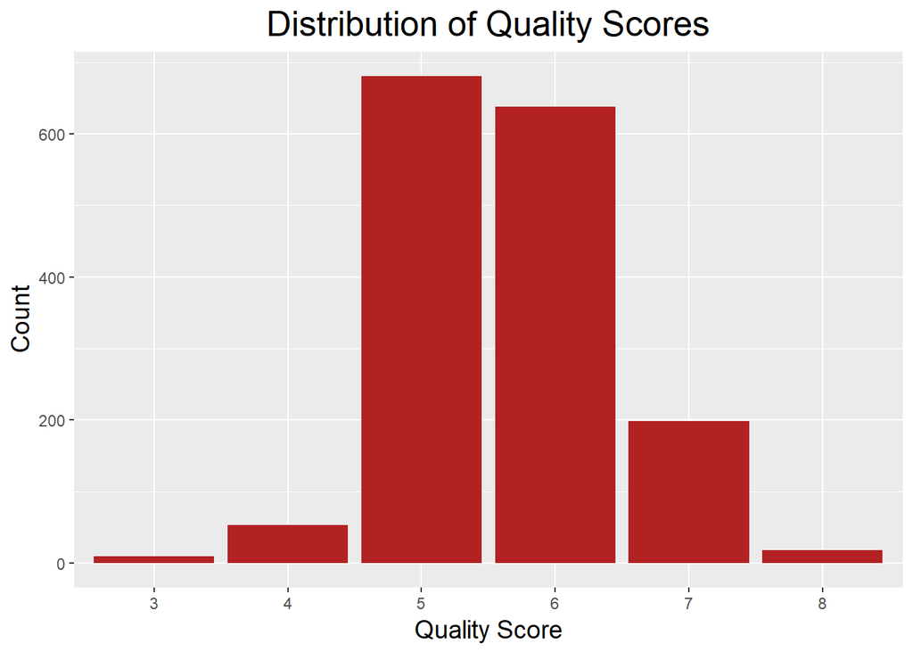

### Description One

The majority of the wine scored 6 or greater. There are not wines that received extremely poor or extremely good ratings. Most wines were found to be of average quality, scoring a 5 or 6.

### Plot Two

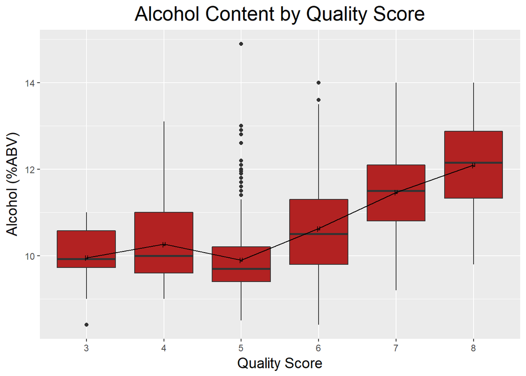

### Description Two

The alcohol content of a wine seems to have a relationship to its score. Higher alcohol contents tending to product higher scoring wines. If the taste testers were made aware of the alcohol content in the wine they were tasting, this could be a significant source of bias.

### Plot Three

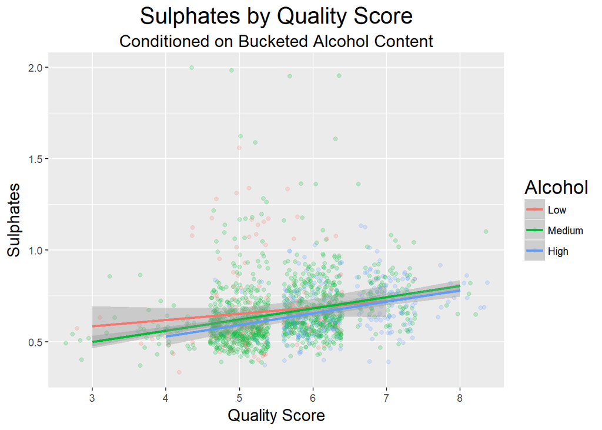

### Description Three

This plot illustrates the slight positive relationship between Sulfate content and the wine’s quality score. For lower alcohol content wines the relationship is blunted slightly. For the “Medium” and “High” alcohol buckets the relationship is consistent, the slopes are roughly equal with the “High” bucket having slightly lower sulfate measurements.

# Reflection

This project has been a strenuous journey. I have learned much along the way. Many times with this data set I was at a loss what and where to explore. I found that doing domain research helped me get unstuck and find a new perspective of these data that allowed me to keep going. I have a deeper appreciation for the subject and the exploratory analysis process. It might be interesting to find a more extensive data set that includes measurements of additional variables that could help explain the quality scores. I think analysis of economic data and region of origin would allow for deeper exploration of the bias and variance in the quality variable.